# Plotting the results of the C++ code

Colin Guétemme

2021-03-02

# Informations

## Libraries and settings

```r
# allow the getActiveDocumentContext() function
library("ggplot2")

# for nice plots
library("rstudioapi")

# set the working directory in the active file
setwd(dirname(getActiveDocumentContext()$path))
```

# The C++ code and the outputs

Based on that this code will output the results in two folder (`distr/...` and `stats/...`).

The `distr/...` folder will contains the distribution of each gametes for the last cycle if the environment is non-stochastic and the last 10 cycles if the environment is stochastic.

The `stats/...` folder will contains the statistical values describe in the article of Burger(2002), respectively:

- the averaged genotypic value
- the averaged genetic variance
- the averaged ratio between the genetic variance and the maximum variance
- the geometric mean fitness

Once a simulation is done, the data will be entered in .csv files whose name are based on the parameters used for the simulation as follow:

- The amplitude of the environment variation times 100 (ex: `a50` for an amplitude of 0.5)
- The period of the environment variation (ex: `L24` for a period of 24 generation)
- The stochastic coefficient times 100 (ex: `d10` for a stochasticity of 0.1)
- The strength of selection (!only integer!, ex:`s5` for a strength of 5)
- The log10 of the mutation rate (!or 0 if null!, ex:`u-5` for a mutation rate of 10^-5)
- The number of loci (ex: `n4` for 4 loci)

Let’s open the following files

```r
stats <- read.csv("stats/a50_L50_d0_s5_u0_n2.csv",
                  sep = "\t", header = TRUE)
distr <-  read.csv("full_distr/a50_L50_d0_s5_u0_n2.csv",
                   sep = "\t", header = TRUE)

head(stats)
```

```
##   sim_num         stat    value
## 1       0     mean_gen 0.291497
## 2       0      var_gen 1.207540
## 3       0        ratio 1.796560
## 4       0 geom_fitness 0.316439
## 5       1     mean_gen 0.287415
## 6       1      var_gen 1.175700
```

```r
head(distr)
```

```
##   sim_num time gamete_num     prop gamete_value
## 1       0    0         -1 0.500000          0.1
## 2       0    1         -1 0.562667          0.1
## 3       0    2         -1 0.624345          0.1
## 4       0    3         -1 0.684062          0.1
## 5       0    4         -1 0.740877          0.1
## 6       0    5         -1 0.793893          0.1
```

Those tables are organized to be directly readable by ggplot2, maybe less practical when it comes to handle the data in the table (will see later if I change it).

In the first table the `sim_num` corresponds to the number of the simulation (Burger advised to do 4000 per set of parameters), `stat` describe which one of the four observed statistics the row corresponds. And `value` is the corresponding value.

In the second table the `sim_num`is the same as before, `time` corresponds to the number of generations (only from the moment where we keep the values, 1 or 10 cycle(s) before the end), `gamete_num` is the number of the gamete, a value of -1 describe the optimum genotype, `prop` is the proportion of this gamete at this time (or the value of the optimum genotype), and `gamete_value` is the value of this particular gamete.

So

```r
num_loci <- 2
num_gamete <- 2^num_loci
L <- 50
```

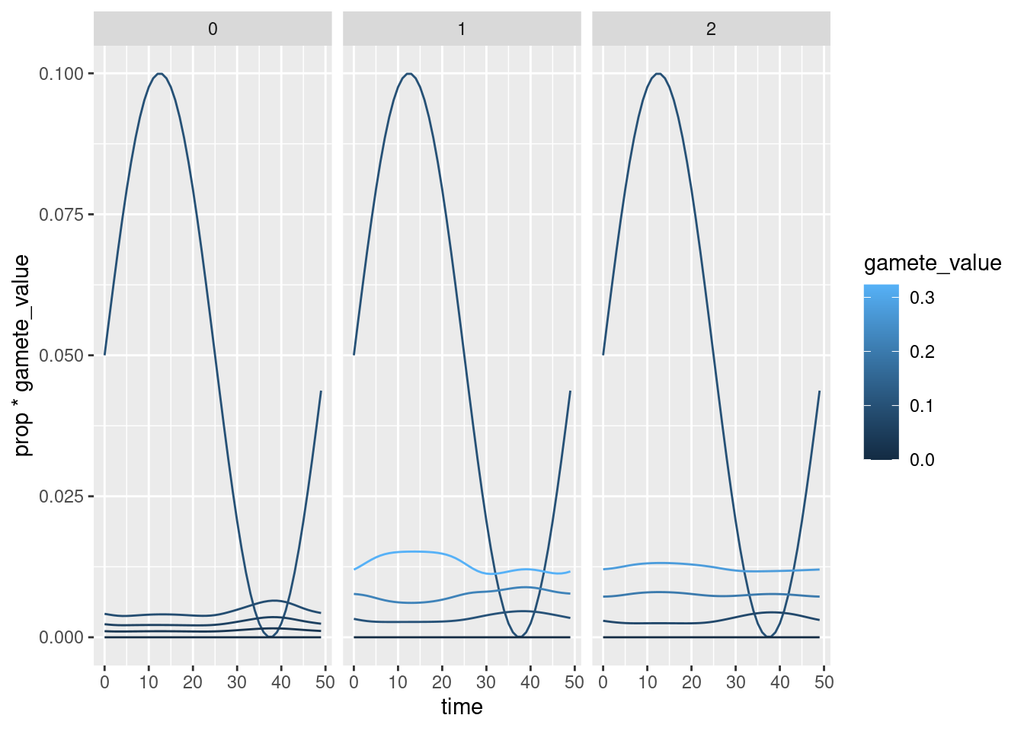

```r
distr <- distr[(1+(0*((num_gamete+1)*L))):(3*((num_gamete+1)*L)), ]
ggplot(distr, aes(x = time, y = prop*gamete_value, color = gamete_value, group = gamete_num)) + geom_line() + facet_grid(.~sim_num)
```

```r
distr <-  read.csv("full_distr/a50_L50_d0_s5_u0_n2.csv", sep = "\t", header = TRUE)
```

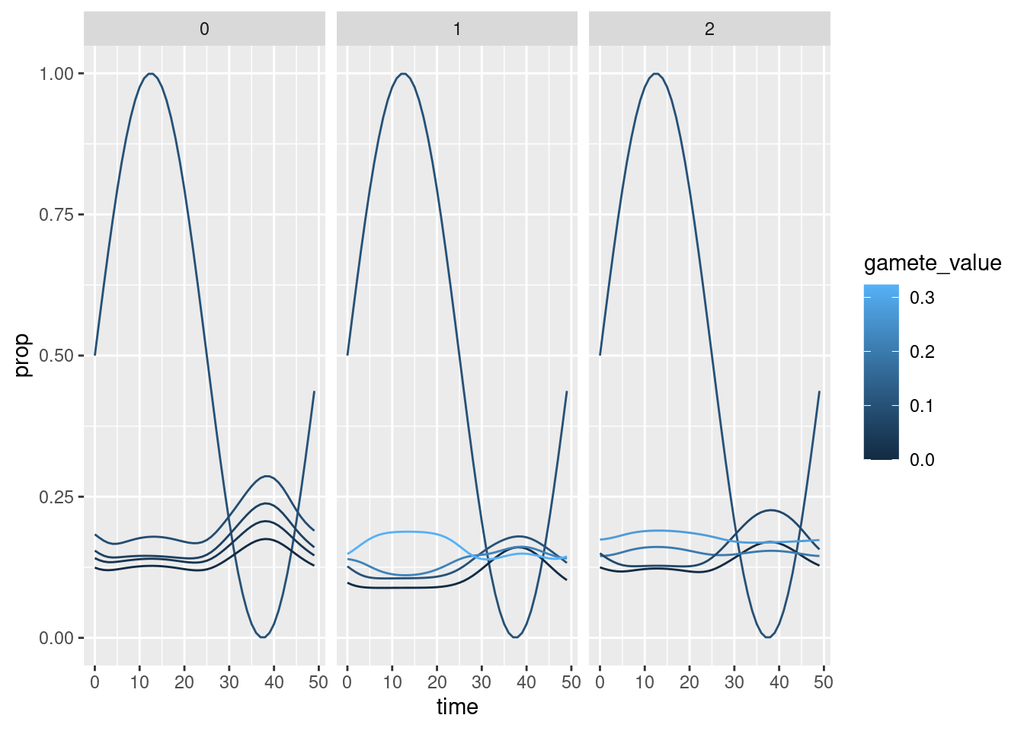

```r
distr <- distr[(1+(0*((num_gamete+1)*L))):(3*((num_gamete+1)*L)), ]
distr$prop[distr$gamete_num >= 0] <- distr$prop[distr$gamete_num >= 0]*num_gamete
ggplot(distr, aes(x = time, y = prop, color = gamete_value, group = gamete_num)) + geom_line() + facet_grid(.~sim_num)
```

```r
distr <-  read.csv("full_distr/a50_L50_d0_s5_u0_n2.csv", sep = "\t", header = TRUE)
```

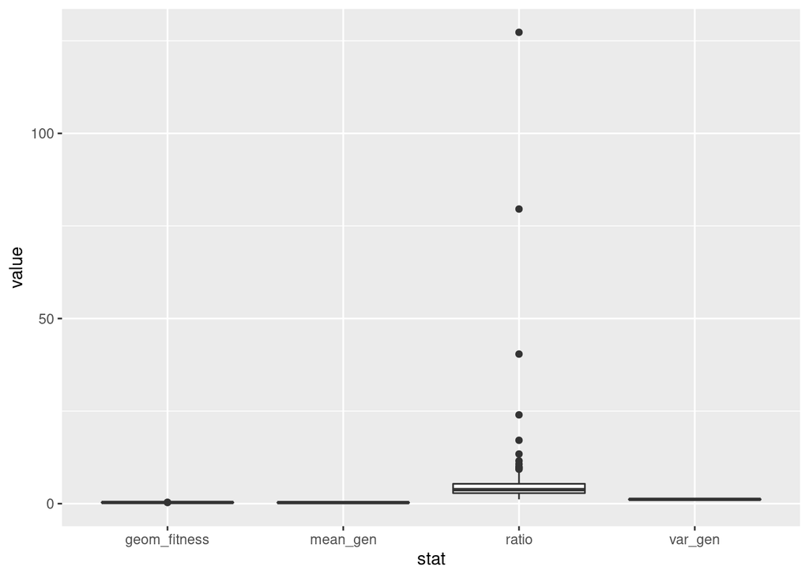

```r
ggplot(stats, aes(x = stat, y = value)) + geom_boxplot()
```

## Comparison of the results with the Article

To compare the results, we need to get them in the same way than in the article, as follow:

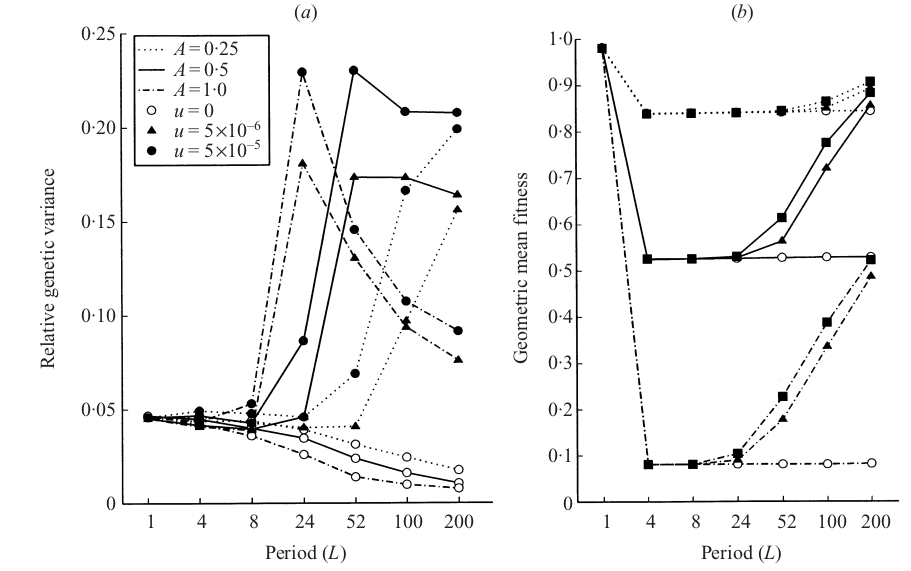

```
##    amplitude mutation stoch selec_s n_loci
## 1       0.25    0e+00     0       5      4
## 2       0.25    5e-06     0       5      4
## 3       0.25    5e-05     0       5      4
## 4       0.50    0e+00     0       5      4
## 5       0.50    5e-06     0       5      4
## 6       0.50    5e-05     0       5      4
## 7       1.00    0e+00     0       5      4
## 8       1.00    5e-06     0       5      4
## 9       1.00    5e-05     0       5      4
## 10      0.50    0e+00     0       5      4
## 11      0.50    5e-07     0       5      4
## 12      0.50    5e-06     0       5      4
## 13      0.50    5e-05     0       5      4
## 14      0.50    5e-04     0       5      4
```

[output not shown]